# Classification & Regression Trees

**Prediction Trees** are used to predict a response or class \( Y \) from input \( X_1, X_2, \ldots, X_n \). If it is a continuous response it's called a regression tree, if it is categorical, it's called a classification tree. At each node of the tree, we check the value of one the input \( X_i \) and depending of the (binary) answer we continue to the left or to the right subbranch. When we reach a leaf we will find the prediction (usually it is a simple statistic of the dataset the leaf represents, like the most common value from the available classes).

Contrary to linear or polynomial regression which are global models (the predictive formula is supposed to hold in the entire data space), trees try to partition the data space into small enough parts where we can apply a simple different model on each part. The non-leaf part of the tree is just the procedure to determine for each data \( x \) what is the model (i.e, which leaf) we will use to classify it.

> One of the most comprehensible non-parametric methods is k-nearest-neighbors: find the points which are most similar to you, and do what, on average, they do. There are two big drawbacks to it: first, you're defining “similar” entirely in terms of the inputs, not the response; second, k is constant everywhere, when some points just might have more very-similar neighbors than others. Trees get around both problems: leaves correspond to regions of the input space (a neighborhood), but one where the responses are similar, as well as the inputs being nearby; and their size can vary arbitrarily. Prediction trees are adaptive nearest-neighbor methods. - From here

## Regression Trees

**Regression Trees** like say linear regression, outputs an expected value given a certain output.

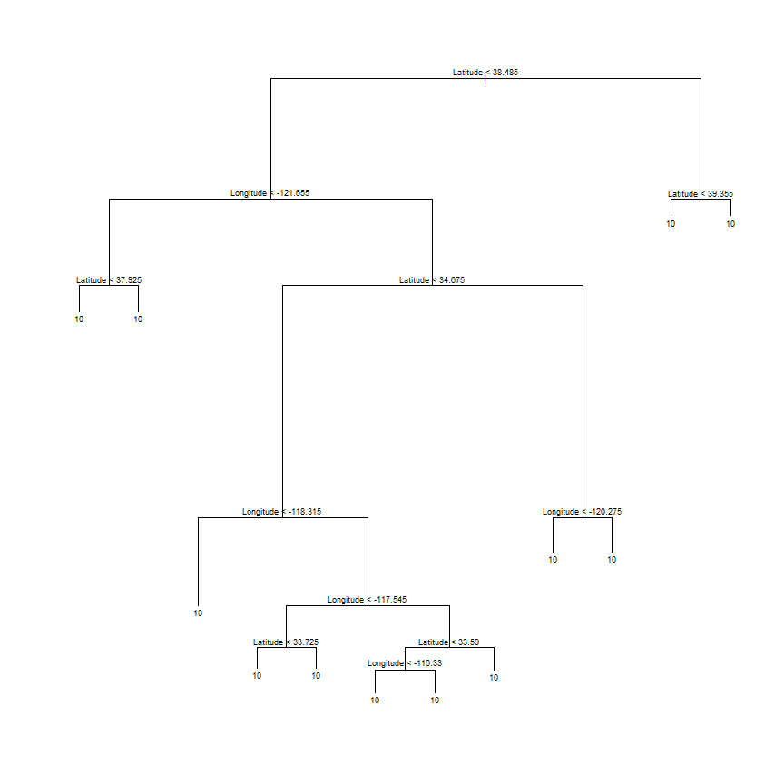

```r
library(tree)

real.estate <- read.table("cadata.dat", header=TRUE)
tree.model <- tree(log(MedianHouseValue) ~ Longitude + Latitude, data=real.estate)
plot(tree.model)
text(tree.model, cex=.75)
```

Notice that the leaf values represent the log of the price, since that was the way we represented the formula in the `tree()` function.

(*note: Knitr seems to output the wrong values above, check the results yourself in R*)

We can compare the predictions with the dataset (darker is more expensive) which seem to capture the global price trend:

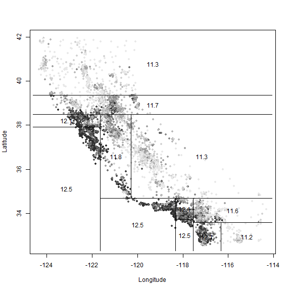

```r
price.deciles <- quantile(real.estate$MedianHouseValue, 0:10/10)
cut.prices    <- cut(real.estate$MedianHouseValue, price.deciles, include.lowest=TRUE)
plot(real.estate$Longitude, real.estate$Latitude, col=grey(10:2/11)[cut.prices], pch=20, xlab="Longitude",ylab="Latitude")
partition.tree(tree.model, ordvars=c("Longitude","Latitude"), add=TRUE)
```

```r
summary(tree.model)
```

```
Regression tree:
tree(formula = log(MedianHouseValue) ~ Longitude + Latitude,
    data = real.estate)
Number of terminal nodes:  12
Residual mean deviance:  0.166 = 3430 / 20600
Distribution of residuals:
   Min. 1st Qu.  Median    Mean 3rd Qu.    Max.
-2.7600 -0.2610 -0.0136  0.0000  0.2630  1.8400
```

Deviance means here the mean squared error.

The flexibility of a tree is basically controlled by how many leaves they have, since that's how many cells they partition things into. The `tree` fitting function has a number of controls settings which limit how much it will grow | each node has to contain a certain number of points, and adding a node has to reduce the error by at least a certain amount. The default for the latter, `min.dev`, is 0:01; let's turn it down and see what happens:

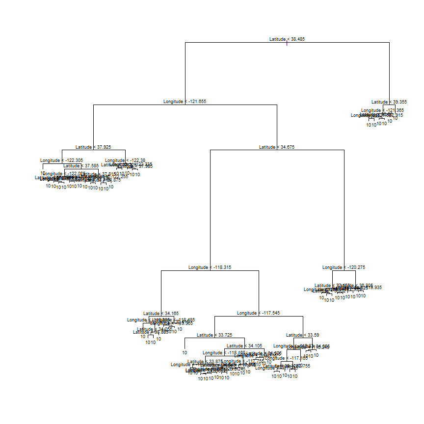

```r
tree.model2 <- tree(log(MedianHouseValue) ~ Longitude + Latitude, data=real.estate, mindev=0.001)
plot(tree.model2)
text(tree.model2, cex=.75)
```

```r
summary(tree.model2)
```

```
Regression tree:
tree(formula = log(MedianHouseValue) ~ Longitude + Latitude,
    data = real.estate, mindev = 0.001)
Number of terminal nodes:  68
Residual mean deviance:  0.105 = 2160 / 20600
Distribution of residuals:
   Min. 1st Qu.  Median    Mean 3rd Qu.    Max.
-2.9500 -0.1980 -0.0187  0.0000  0.2000  1.6100
```

It's obviously much finer-grained than the previous example (68 leafs against 12), and does a better job of matching the actual prices (lower error).

Also, we can include all the variables, not only the latitude and longitude:

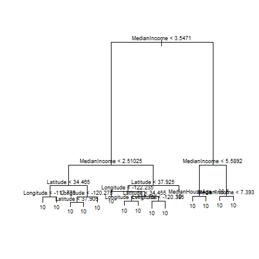

```r
tree.model3 <- tree(log(MedianHouseValue) ~ ., data=real.estate)
plot(tree.model3)
text(tree.model3, cex=.75)
```

```r
summary(tree.model3)
```

```
Regression tree:
tree(formula = log(MedianHouseValue) ~ ., data = real.estate)
Variables actually used in tree construction:
[1] "MedianIncome"   "Latitude"       "Longitude"      "MedianHouseAge"
Number of terminal nodes:  15
Residual mean deviance:  0.132 = 2720 / 20600
Distribution of residuals:
   Min. 1st Qu.  Median    Mean 3rd Qu.    Max.
-2.8600 -0.2270 -0.0147  0.0000  0.2070  2.0400
```

## Classification Trees

Classification trees output the predicted class for a given sample.

Let's use here the iris dataset (and split it into train and test sets):

```r
set.seed(101)
alpha     <- 0.7 # percentage of training set
inTrain   <- sample(1:nrow(iris), alpha * nrow(iris))
train.set <- iris[inTrain,]
test.set  <- iris[-inTrain,]
```

There are two options for the output:

- Point prediction: simply gives the predicted class
- Distributional prediction: gives a probability for each class

```r
library(tree)

tree.model <- tree(Species ~ Sepal.Width + Petal.Width, data=train.set)
tree.model
```

```
node), split, n, deviance, yval, (yprob)
      * denotes terminal node

 1) root 105 200 versicolor ( 0.33 0.36 0.30 )
   2) Petal.Width < 0.8 35   0 setosa ( 1.00 0.00 0.00 ) *
   3) Petal.Width > 0.8 70 100 versicolor ( 0.00 0.54 0.46 )
     6) Petal.Width < 1.7 40  20 versicolor ( 0.00 0.92 0.07 )
      12) Petal.Width < 1.35 20   0 versicolor ( 0.00 1.00 0.00 ) *
      13) Petal.Width > 1.35 20  20 versicolor ( 0.00 0.85 0.15 )
        26) Sepal.Width < 3.05 14  10 versicolor ( 0.00 0.79 0.21 ) *
        27) Sepal.Width > 3.05 6   0 versicolor ( 0.00 1.00 0.00 ) *
     7) Petal.Width > 1.7 30   9 virginica ( 0.00 0.03 0.97 )
      14) Petal.Width < 1.85 8   6 virginica ( 0.00 0.12 0.88 ) *
      15) Petal.Width > 1.85 22   0 virginica ( 0.00 0.00 1.00 ) *
```

```r
summary(tree.model)
```

```
Classification tree:
tree(formula = Species ~ Sepal.Width + Petal.Width, data = train.set)
Number of terminal nodes:  6
Residual mean deviance:  0.208 = 20.6 / 99
Misclassification error rate: 0.0381 = 4 / 105
```

```r
# Distributional prediction
my.prediction <- predict(tree.model, test.set) # gives the probability for each class
head(my.prediction)
```

```
   setosa versicolor virginica
5       1          0         0
10      1          0         0
12      1          0         0
15      1          0         0
16      1          0         0
18      1          0         0
```

```r
# Point prediction
# Let's translate the probability output to categorical output
maxidx <- function(arr) {
    return(which(arr == max(arr)))
}
idx <- apply(my.prediction, c(1), maxidx)
prediction <- c('setosa', 'versicolor', 'virginica')[idx]
table(prediction, test.set$Species)
```

```
prediction   setosa versicolor virginica
  setosa         15          0         0
  versicolor      0         11         1
  virginica       0          1        17
```

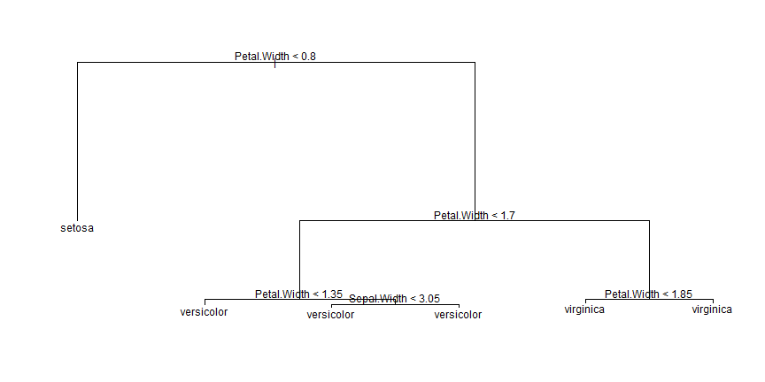

```r
plot(tree.model)
text(tree.model)
```

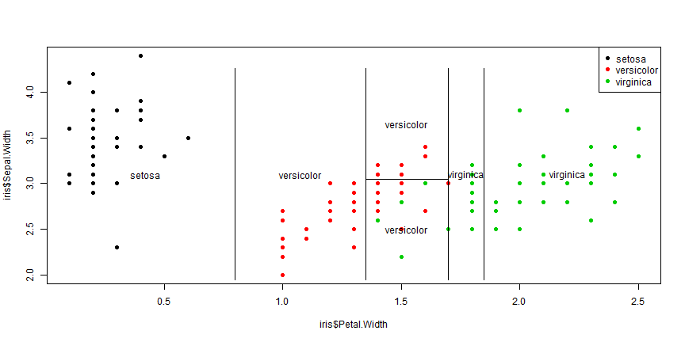

```r
# Another way to show the data:
plot(iris$Petal.Width, iris$Sepal.Width, pch=19, col=as.numeric(iris$Species))
partition.tree(tree.model, label="Species", add=TRUE)
legend("topright",legend=unique(iris$Species), col=unique(as.numeric(iris$Species)), pch=19)
```

```r
summary(tree.model)
```

```
Classification tree:
tree(formula = Species ~ Sepal.Width + Petal.Width, data = train.set)
Number of terminal nodes:  6
Residual mean deviance:  0.208 = 20.6 / 99
Misclassification error rate: 0.0381 = 4 / 105
```

We can prune the tree to prevent overfitting. The next function `prune.tree()` allows us to choose how many leafs we want the tree to have, and it returns the best tree with that size.

The argument `newdata` accepts new input for making the prune decision. If new data is not given, the method uses the original dataset from which the tree model was built.

For classification trees we can also use argument `method="misclass"` so that the pruning measure should be the number of misclassifications.

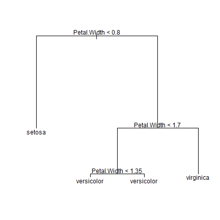

```r
pruned.tree <- prune.tree(tree.model, best=4)
plot(pruned.tree)
text(pruned.tree)
```

```r
pruned.prediction <- predict(pruned.tree, test.set, type="class") # give the predicted class
table(pruned.prediction, test.set$Species)
```

```
pruned.prediction setosa versicolor virginica
       setosa         15          0         0
       versicolor      0         11         1
       virginica       0          1        17
```

This package can also do K-fold cross-validation using `cv.tree()` to find the best tree:

```r
# here, let's use all the variables and all the samples
tree.model <- tree(Species ~ ., data=iris)
summary(tree.model)
```

```
Classification tree:
tree(formula = Species ~ ., data = iris)
Variables actually used in tree construction:
[1] "Petal.Length" "Petal.Width"  "Sepal.Length"
Number of terminal nodes:  6
Residual mean deviance:  0.125 = 18 / 144
Misclassification error rate: 0.0267 = 4 / 150
```

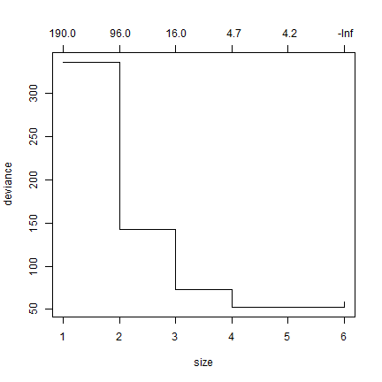

```r
cv.model <- cv.tree(tree.model)
plot(cv.model)
```

```r
cv.model$dev  # gives the deviance for each K (small is better)
```

```
[1]  59.09  52.62  52.58  73.34 142.82 336.22
```

```r
best.size <- cv.model$size[which(cv.model$dev==min(cv.model$dev))] # which size is better?
best.size
```

```
[1] 4
```

```r
# let's refit the tree model (the number of leafs will be no more than best.size)
cv.model.pruned <- prune.misclass(tree.model, best=best.size)
summary(cv.model.pruned)
```

```
Classification tree:
snip.tree(tree = tree.model, nodes = c(7L, 12L))
Variables actually used in tree construction:
[1] "Petal.Length" "Petal.Width"
Number of terminal nodes:  4
Residual mean deviance:  0.185 = 27 / 146
Misclassification error rate: 0.0267 = 4 / 150
```

## Package `rpart`

This package is faster than `tree`.

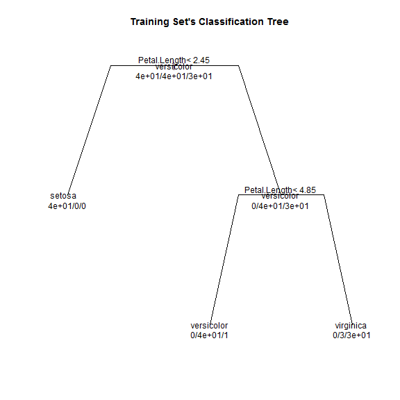

```r
library(rpart)

rpart.tree <- rpart(Species ~ ., data=train.set)
plot(rpart.tree, uniform=TRUE, branch=0.6, margin=0.05)
text(rpart.tree, all=TRUE, use.n=TRUE)
title("Training Set's Classification Tree")
```

```r
predictions <- predict(rpart.tree, test.set, type="class")
table(test.set$Species, predictions)
```

```
            predictions
             setosa versicolor virginica
  setosa         15          0         0
  versicolor      0         11         1
  virginica       0          2        16
```

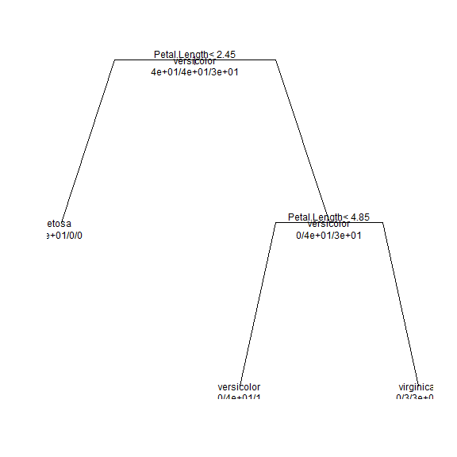

```r
prune.rpart.tree <- prune(rpart.tree, cp=0.02) # pruning the tree
plot(prune.rpart.tree, uniform=TRUE, branch=0.6)
text(prune.rpart.tree, all=TRUE, use.n=TRUE)
```

An eg with different costs for errors:

```r
lmat <- matrix(c(0,1,2,
                 1,0,100,
                 2,100,0), ncol = 3)
lmat
```

```
     [,1] [,2] [,3]
[1,]    0    1    2
[2,]    1    0  100
[3,]    2  100    0
```

So, misclassifying the 2nd class for the 3rd (or vice-versa) is highly costly.

```r
rpart.tree <- rpart(Species ~ ., data=train.set, parms = list(loss = lmat))
predictions <- predict(rpart.tree, test.set, type="class")
table(test.set$Species, predictions)
```

```
            predictions
             setosa versicolor virginica
  setosa         15          0         0
  versicolor      2         10         0
  virginica       6          1        11
```

As we see, the algorithm made a different tree to minimize the costly errors.

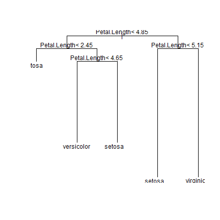

```r
plot(rpart.tree)
text(rpart.tree)
```

A plotting function to better control the parameters:

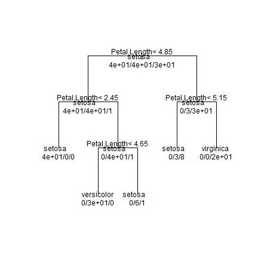

```r
## Define a plotting function with decent defaults
plot.rpart.obj <- function(rpart.obj, font.size = 0.8) {
    ## plot decision tree
    plot(rpart.obj,
         uniform   = T,    # if 'TRUE', uniform vertical spacing of the nodes is used
         branch    = 1,    # controls the shape of the branches from parent to child node
         compress  = F,    # if 'FALSE', the leaf nodes will be at the horizontal plot
         nspace    = 0.1,
         margin    = 0.1, # an extra fraction of white space to leave around the borders
         minbranch = 0.3)  # set the minimum length for a branch

    ## Add text
    text(x      = rpart.obj,   #
         splits = T,           # If tree are labeled with the criterion for the split
         all    = T,           # If 'TRUE', all nodes are labeled, otherwise just terminal nodes
         use.n  = T,           # Use numbers to annotate
         cex    = font.size)   # Font size
}

plot.rpart.obj(rpart.tree, 1)
```

The package `party` gives better plotting and text functions:

```r
library(partykit)

rparty.tree <- as.party(rpart.tree)
rparty.tree
```

```
Model formula:
Species ~ Sepal.Length + Sepal.Width + Petal.Length + Petal.Width

Fitted party:
[1] root
|   [2] Petal.Length < 4.85
|   |   [3] Petal.Length < 2.45: setosa (n = 35, err = 0%)
|   |   [4] Petal.Length >= 2.45
|   |   |   [5] Petal.Length < 4.65: versicolor (n = 29, err = 0%)
|   |   |   [6] Petal.Length >= 4.65: versicolor (n = 7, err = 14%)
|   [7] Petal.Length >= 4.85
|   |   [8] Petal.Length < 5.15: virginica (n = 11, err = 27%)
|   |   [9] Petal.Length >= 5.15: virginica (n = 23, err = 0%)

Number of inner nodes:    4
Number of terminal nodes: 5
```

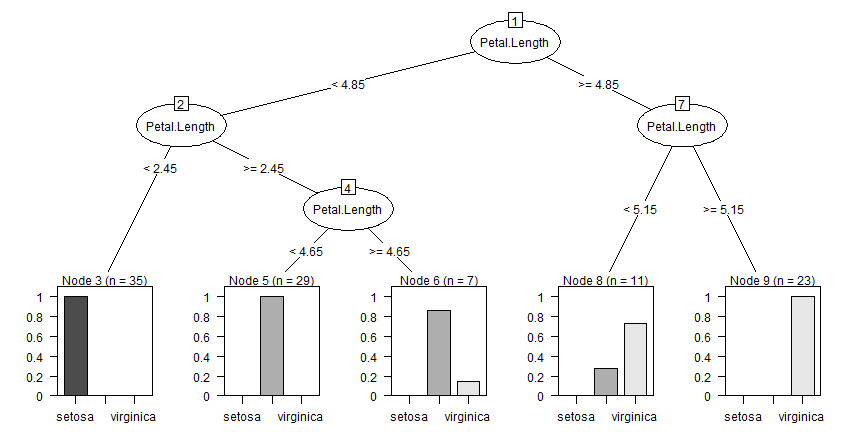

```r
plot(rparty.tree)
```

Just another eg, this time a regression tree:

```r
fit <- rpart(Mileage~Price + Country + Reliability + Type, method="anova", data=cu.summary)
printcp(fit) # display the results
```

```
Regression tree:
rpart(formula = Mileage ~ Price + Country + Reliability + Type,
    data = cu.summary, method = "anova")

Variables actually used in tree construction:
[1] Price Type

Root node error: 1355/60 = 23

n=60 (57 observations deleted due to missingness)

     CP nsplit rel error xerror  xstd
1 0.623      0      1.00   1.02 0.178
2 0.132      1      0.38   0.54 0.104
3 0.025      2      0.25   0.38 0.085
4 0.012      3      0.22   0.38 0.088
5 0.010      4      0.21   0.40 0.088
```

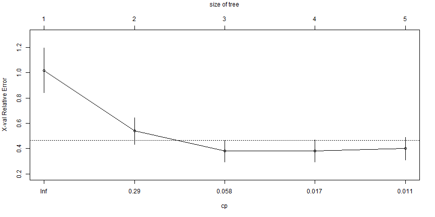

```r
plotcp(fit) # visualize cross-validation results
```

```r
summary(fit) # detailed summary of splits
```

```
Call:
rpart(formula = Mileage ~ Price + Country + Reliability + Type,
    data = cu.summary, method = "anova")
  n=60 (57 observations deleted due to missingness)

       CP nsplit rel error xerror    xstd
1 0.62289      0    1.0000 1.0194 0.17820
2 0.13206      1    0.3771 0.5389 0.10441
3 0.02544      2    0.2451 0.3806 0.08544
4 0.01160      3    0.2196 0.3835 0.08766
5 0.01000      4    0.2080 0.3999 0.08764

Variable importance
  Price    Type Country
     48      42      10

Node number 1: 60 observations,    complexity param=0.6229
  mean=24.58, MSE=22.58
  left son=2 (48 obs) right son=3 (12 obs)
  Primary splits:
      Price       < 9446  to the right,  improve=0.6229, (0 missing)
      Type        splits as  LLLRLL,     improve=0.5044, (0 missing)
      Reliability splits as  LLLRR,      improve=0.1263, (11 missing)
      Country     splits as  --LRLRRRLL, improve=0.1244, (0 missing)
  Surrogate splits:
      Type    splits as  LLLRLL,     agree=0.950, adj=0.750, (0 split)
      Country splits as  --LLLLRRLL, agree=0.833, adj=0.167, (0 split)

Node number 2: 48 observations,    complexity param=0.1321
  mean=22.71, MSE=8.498
  left son=4 (23 obs) right son=5 (25 obs)
  Primary splits:
      Type        splits as  RLLRRL,     improve=0.43850, (0 missing)
      Price       < 12150 to the right,  improve=0.25750, (0 missing)
      Country     splits as  --RRLRL-LL, improve=0.13350, (0 missing)
      Reliability splits as  LLLRR,      improve=0.01637, (10 missing)
  Surrogate splits:
      Price   < 12220 to the right,  agree=0.812, adj=0.609, (0 split)
      Country splits as  --RRLRL-RL, agree=0.646, adj=0.261, (0 split)

```

[output cut: 21 more lines]

```
  Surrogate splits:
      Country splits as  --LLLL--LR, agree=0.80, adj=0.545, (0 split)
      Type    splits as  L--RL-,     agree=0.64, adj=0.182, (0 split)

Node number 8: 10 observations
  mean=19.3, MSE=2.21

Node number 9: 13 observations
  mean=21.77, MSE=0.7929

Node number 10: 14 observations
  mean=23.86, MSE=7.694

Node number 11: 11 observations
  mean=25.45, MSE=3.521
```

[output not shown]

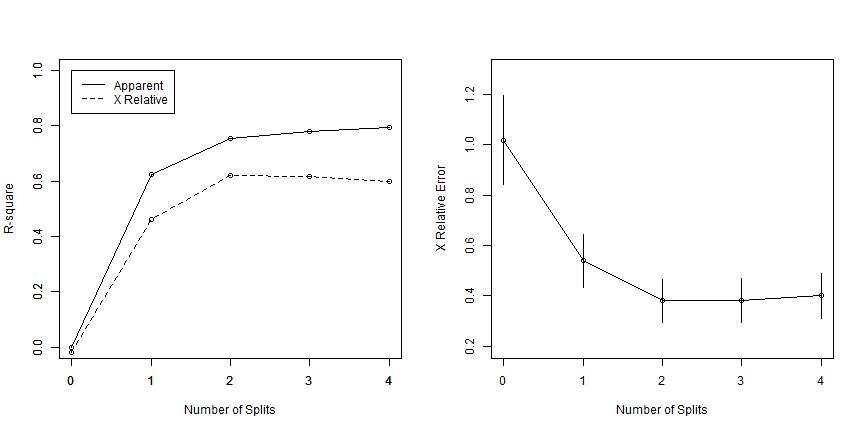

```r
# create additional plots
par(mfrow=c(1,2)) # two plots on one page
rsq.rpart(fit) # visualize cross-validation results
```

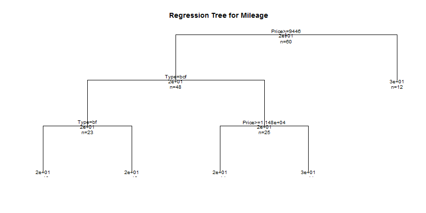

```r
par(mfrow=c(1,1))

# plot tree
plot(fit, uniform=TRUE, main="Regression Tree for Mileage ")
text(fit, use.n=TRUE, all=TRUE, cex=.8)
```

```r
# create attractive postcript plot of tree
post(fit, file = "c:/tree2.ps", title = "Regression Tree for Mileage ")
```

## Random Forests

> Random forests are an ensemble learning method for classification (and regression) that operate by constructing a multitude of decision trees at training time and outputting the class that is the mode of the classes output by individual trees – [Wikipedia](http://en.wikipedia.org/wiki/Random_forest)

Check the [manual](http://cran.r-project.org/web/packages/randomForest/randomForest.pdf) for options and available tools.

```r
library("randomForest")

r <- randomForest(Species ~., data=train.set, importance=TRUE, do.trace=100, ntree=100)
```

```
ntree      OOB      1      2      3
  100:   4.76%  0.00%  5.26%  9.38%
```

```r
print(r)
```

```
Call:
 randomForest(formula = Species ~ ., data = train.set, importance = TRUE,      do.trace = 100, ntree = 100)
               Type of random forest: classification
                     Number of trees: 100
No. of variables tried at each split: 2

        OOB estimate of  error rate: 4.76%
Confusion matrix:
           setosa versicolor virginica class.error
setosa         35          0         0     0.00000
versicolor      0         36         2     0.05263
virginica       0          3        29     0.09375
```

```r
predictions <- predict(r, test.set)
table(test.set$Species, predictions)
```

```
            predictions
             setosa versicolor virginica
  setosa         15          0         0
  versicolor      0         12         0
  virginica       0          3        15
```

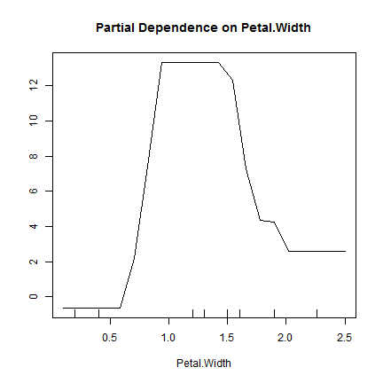

```r
# next function gives a graphical depiction of the marginal effect of a variable on the class probability (classification) or response (regression).
partialPlot(r, train.set, Petal.Width, "versicolor")
```

We can extract a given tree or get some information about the ensemble.

```r
t <- getTree(r, k=2) # get the second tree
print(t)
```

```
   left daughter right daughter split var split point status prediction
1              2              3         3        2.60      1          0
2              0              0         0        0.00     -1          1
3              4              5         1        6.05      1          0
4              6              7         4        1.75      1          0
5              8              9         4        1.55      1          0
6              0              0         0        0.00     -1          2
7              0              0         0        0.00     -1          3
8             10             11         3        5.00      1          0
9              0              0         0        0.00     -1          3
10             0              0         0        0.00     -1          2
11             0              0         0        0.00     -1          3
```

```r
treesize(r) # size of trees of the ensemble
```

```
  [1]  6  6  6  8  6  6  9  8  5  8  7  8  7  5  7  6  8  4  4  5  5  8  8
 [24]  7  5  5  6  8  9  6  5  8  7  7  6  9  5  8  7  7  6  9  6  8  7  5
 [47]  9 11  3  7  6  3  7  5  5  5 10 11  8  6  5  8  5  9  6  7  5  6  8
 [70]  8 10  7  8  5  6  7  6  4  7  7  6  8  7  7  6  3  5  6  8  8  6  7
 [93]  7 10  6  8  6  8  5  8
```

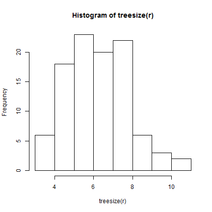

```r
hist(treesize(r))
```

We can also tune the structure, ie, finding the best hyperparameters of the method via grid search:

```r
library("e1071") # to access 'tune' method

tuned.r <- tune(randomForest, train.x = Species ~ .,
                data = train.set,
                validation.x = test.set)

best.model <- tuned.r$best.model
predictions <- predict(best.model, test.set)
table.random.forest <- table(test.set$Species, predictions)
table.random.forest
```

```
            predictions
             setosa versicolor virginica
  setosa         15          0         0
  versicolor      0         11         1
  virginica       0          3        15
```

```r
# computing overall error:
error.rate <- 1 - sum(diag(as.matrix(table.random.forest))) / sum(table.random.forest)
error.rate
```

```
[1] 0.08889
```

## Conditional Inference Trees

> Conditional inference trees estimate a regression relationship by binary recursive partitioning in a conditional inference framework. Roughly, the algorithm works as follows: 1) Test the global null hypothesis of independence between any of the input variables and the response (which may be multivariate as well). Stop if this hypothesis cannot be rejected. Otherwise select the input variable with strongest association to the resonse. This association is measured by a p-value corresponding to a test for the partial null hypothesis of a single input variable and the response. 2) Implement a binary split in the selected input variable. 3) Recursively repeat steps 1) and 2) – party package help file

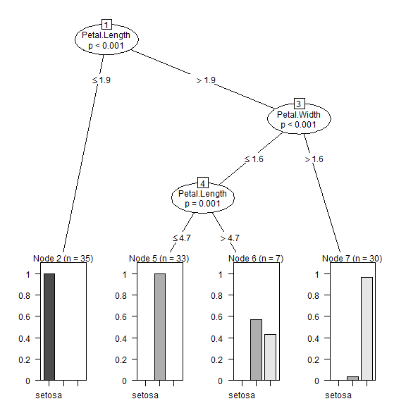

```r
library(party)

iris.model <- ctree(Species ~ . , data = train.set)
plot(iris.model)
```

```r
predictions <- predict(iris.model, test.set[,-5])
table(predictions, test.set$Species)
```

```
predictions  setosa versicolor virginica
  setosa         15          0         0
  versicolor      0         11         1
  virginica       0          1        17
```

```r
# what are the predicted probabilities for the given samples?
treeresponse(iris.model, newdata=iris[c(10,87,128),])
```

```
[[1]]
[1] 1 0 0

[[2]]
[1] 0 1 0

[[3]]
[1] 0.00000 0.03333 0.96667
```

```r
# get the probabilities from the barplots showen above:
tapply(treeresponse(iris.model), where(iris.model), unique)
```

```
$`2`
[1] 1 0 0

$`5`
[1] 0 1 0

$`6`
[1] 0.0000 0.5714 0.4286

$`7`
[1] 0.00000 0.03333 0.96667
```

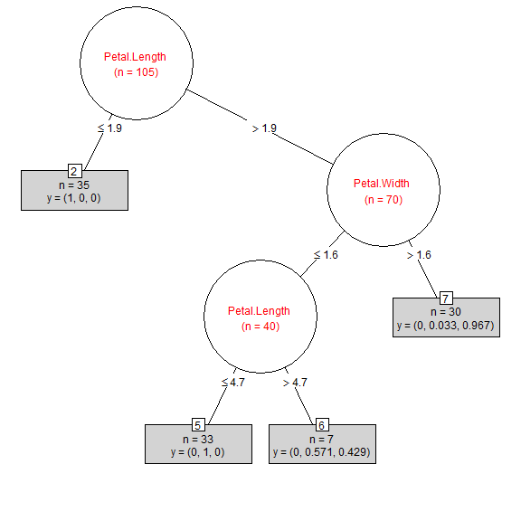

```r
# The package is able to format the plot tree. Eg:
innerWeights <- function(node){
  grid.circle(gp = gpar(fill = "White", col = 1))
  mainlab <- paste( node$psplit$variableName, "\n(n = ")
  mainlab <- paste(mainlab, sum(node$weights),")" , sep = "")
  grid.text(mainlab,gp = gpar(col='red'))
}
plot(iris.model, type='simple', inner_panel = innerWeights)
```